# Introduction

# For Every Year Show which Country was in the Lead in terms of Total Number of Launches up to and including including 2020)

Do the results change if we only look at the number of successful launches?

```python
df_data_country=df_data.groupby(["Year","Country"])
df_data_country=pd.DataFrame(df_data_country["Location"].count()).reset_index().rename(columns={'Location':'Count'})
df_data_country
```

|  | Year | Country | Count |
| --- | --- | --- | --- |
| 0 | 1957 | Kazakhstan | 2 |
| 1 | 1957 | USA | 1 |
| 2 | 1958 | Kazakhstan | 5 |
| 3 | 1958 | USA | 23 |
| 4 | 1959 | Kazakhstan | 4 |
| ... | ... | ... | ... |
| 427 | 2020 | Japan | 3 |
| 428 | 2020 | Kazakhstan | 6 |
| 429 | 2020 | New Zealand | 3 |
| 430 | 2020 | Russia | 3 |
| 431 | 2020 | USA | 21 |

432 rows × 3 columns

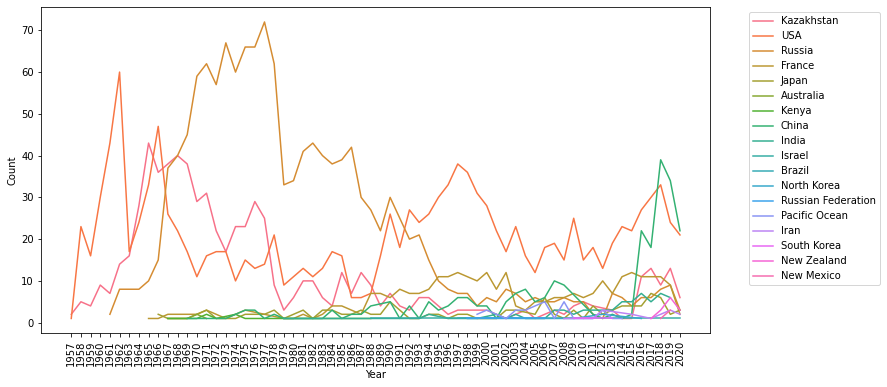

```python
plt.figure(figsize=(12, 6))
sns.lineplot(x='Year', y='Count', data=df_data_country,hue='Country')
plt.legend(bbox_to_anchor=(1.05, 1), loc='upper left')
plt.xticks(rotation=90)
plt.show()
```

```python
df_data_country_success=df_data[df_data["Mission_Status"]=="Success"].groupby(["Country","Year"])
df_data_country_success=pd.DataFrame(df_data_country_success["Location"].count()).reset_index().rename(columns={'Location':'Count'})
df_data_country_success=df_data_country_success.sort_values(by="Year")
df_data_country_success
```

|  | Country | Year | Count |
| --- | --- | --- | --- |
| 175 | Kazakhstan | 1957 | 2 |
| 176 | Kazakhstan | 1958 | 1 |
| 325 | USA | 1958 | 5 |
| 177 | Kazakhstan | 1959 | 2 |
| 326 | USA | 1959 | 6 |
| ... | ... | ... | ... |
| 174 | Japan | 2020 | 3 |
| 45 | China | 2020 | 19 |
| 237 | Kazakhstan | 2020 | 6 |
| 247 | New Zealand | 2020 | 2 |
| 387 | USA | 2020 | 20 |

388 rows × 3 columns

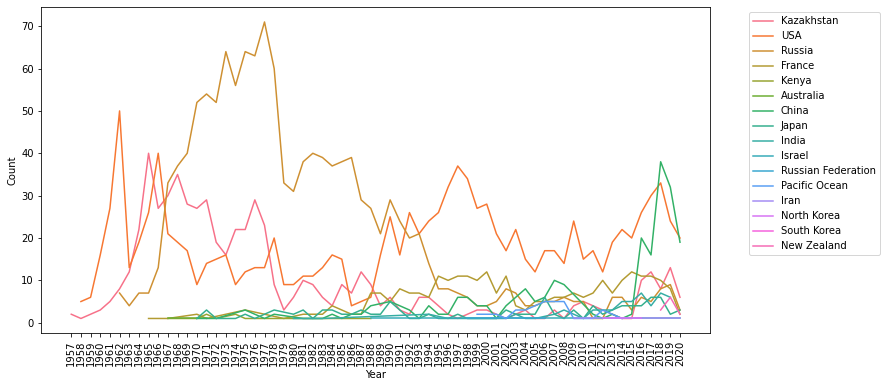

```python
plt.figure(figsize=(12, 6))
sns.lineplot(x='Year', y='Count', data=df_data_country_success,hue='Country')
plt.legend(bbox_to_anchor=(1.05, 1), loc='upper left')
plt.xticks(rotation=90)
plt.show()
#In case of Succes we observe that Russia had been successful overall and in the recent years USA and China have had most number of successes
```

# Create a Year-on-Year Chart Showing the Organisation Doing the Most Number of Launches

Which organisation was dominant in the 1970s and 1980s? Which organisation was dominant in 2018, 2019 and 2020?

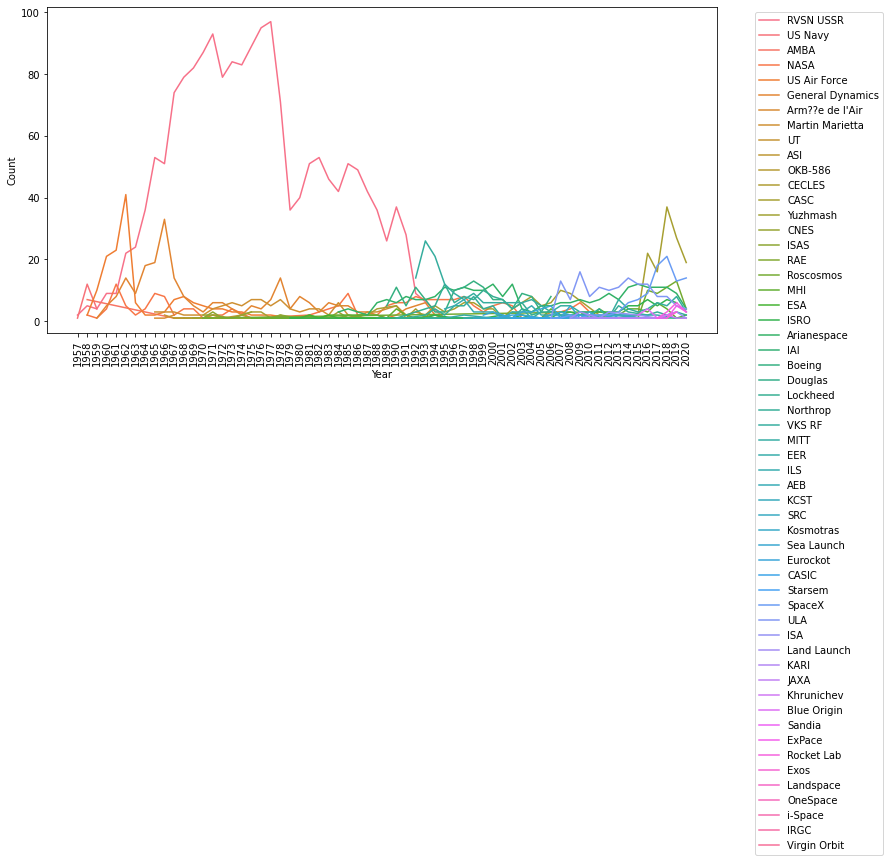

```python
plt.figure(figsize=(12, 6))
sns.lineplot(x='Year', y='Count', data=orgs, hue='Organisation')
plt.legend(bbox_to_anchor=(1.05, 1), loc='upper left')
plt.xticks(rotation=90)
plt.show()
#In the 1970s and 1980s the  Russia's RVSN USSR was dominant
#In 2018,2019 and 2020 China's CASC was dominant
```